# Independent Week 13

# Bivariate Analysis

This analysis involves two variables being observed against each other.

- Correlation Matrix

```r
#Creating a dataframe Cr:
Cr<- Online

#Converting Month and Visitor Type to Numerical:
Cr$Month<- as.numeric(Cr$Month)
Cr$VisitorType<- as.numeric(Cr$VisitorType)
```

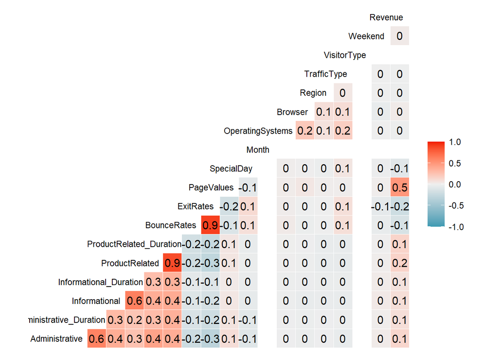

```r
Cr$Weekend<- as.numeric(Cr$Weekend)
Cr$Revenue<- as.numeric(Cr$Revenue)

#Visualizing the Plot
corr_map <- ggcorr(Cr[, 1:18], method=c("everything", "pearson"), label=TRUE, hjust = .90, size = 3, layout.exp = 2)
corr_map
```

- There is a Strong Positive correlation of 0.9 between Exit Rate and Bounce Rate
- Administrative and Administrative duration have a Moderate correlation of 0.6
- Informational and Informational Duration have a Moderate correlation of 0.6
- Product Related and Product Related Duration have a Strong Positive correlation of 0.9
- Revenue has a Moderate correlation of 0.5 with Page value.

The data has a presence of Mullticollinearity.

This analysis seeks to further answer:

- Do Special Days generate the most Revenue

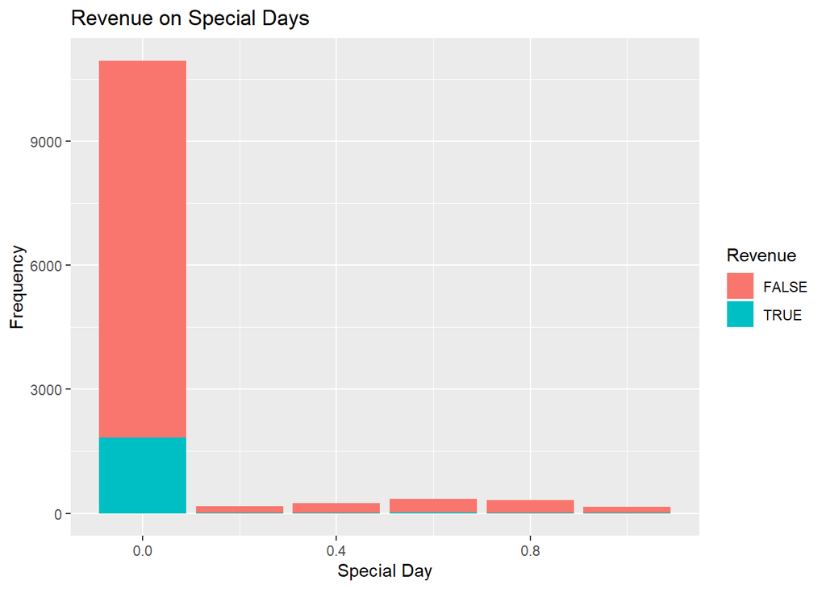

```r
#Plotting a count to understand the relationship between Special Day and Revenue:
Online %>% ggplot() +aes(x = SpecialDay, Revenue = ..count../nrow(Online), fill = Revenue) +geom_bar() +
  labs(title = 'Revenue on Special Days', x = 'Special Day', y = 'Frequency')
```

Most of the Revenue generated was on days not associated with Special days.

- Does Region affect Revenue

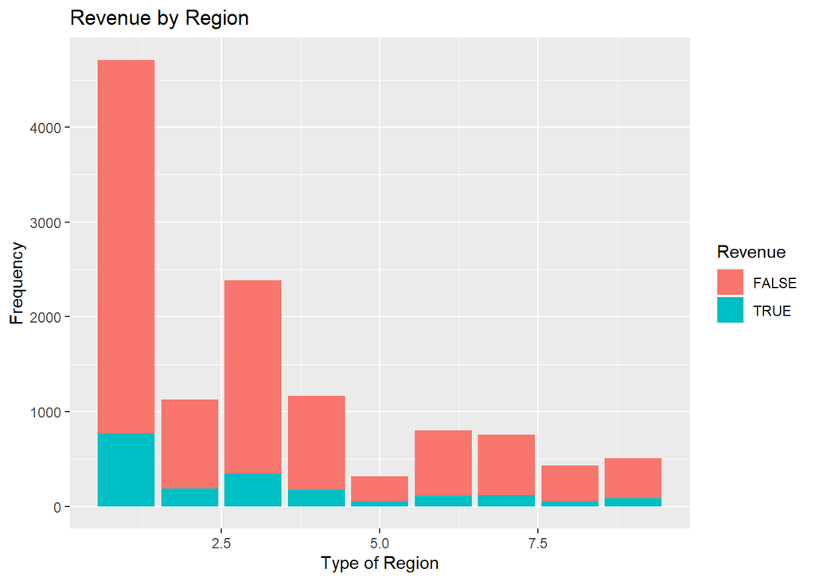

```r
#Plotting a count to understand the relationship between Region and Revenue:
Online %>% ggplot() +aes(x = Region, Revenue = ..count../nrow(Online), fill = Revenue) +geom_bar() +
  labs(title = 'Revenue by Region', x = 'Type of Region', y = 'Frequency')
```

Region 1 with the most visitors generated the highest amount of Revenue.

- Does Type of Traffic affect revenue

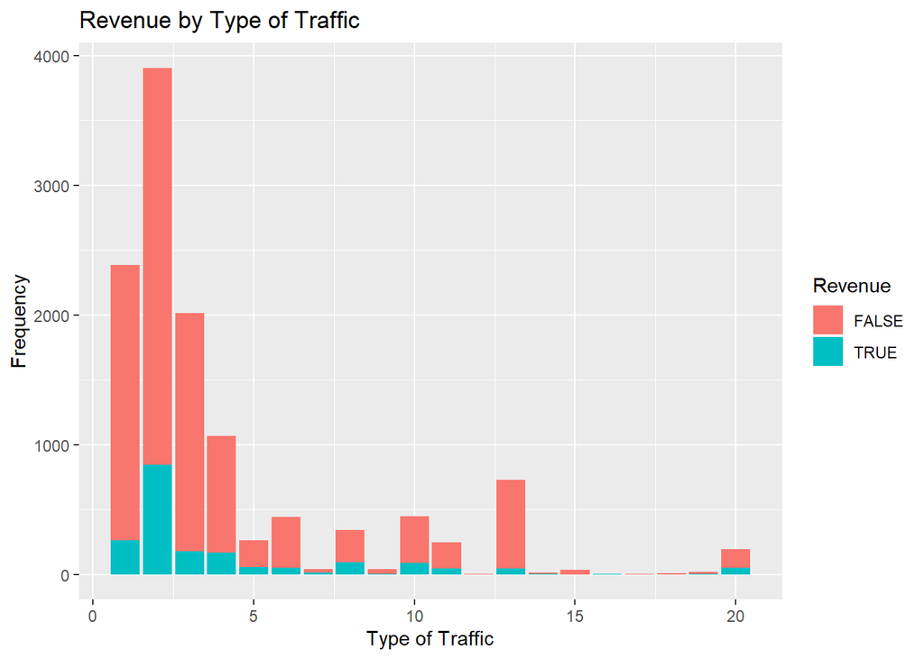

```r
#Plotting a count to understand the relationship between Type of Traffic and Revenue:
Online %>% ggplot() +aes(x = TrafficType, Revenue = ..count../nrow(Online), fill = Revenue) +geom_bar() +
  labs(title = 'Revenue by Type of Traffic', x = 'Type of Traffic', y = 'Frequency')
```

Traffic Type 2 with most users had the highest amount of Revenue.

- Which Browser Generates the Highest Revenue

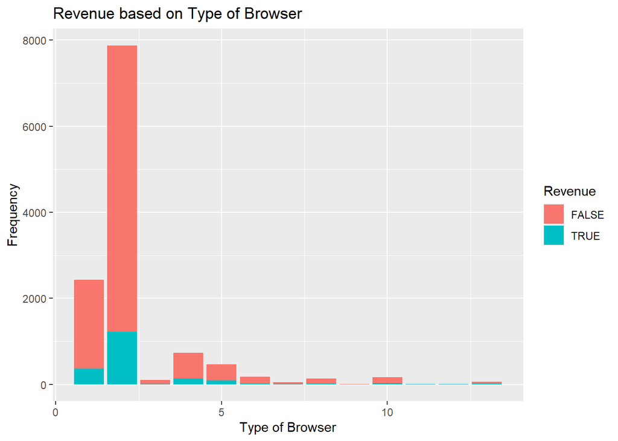

```r
#Plotting a count to understand the relationship between Type of Browser and Revenue:
Online %>% ggplot() +aes(x = Browser, Revenue = ..count../nrow(Online), fill = Revenue) +geom_bar() +
  labs(title = 'Revenue based on Type of Browser', x = 'Type of Browser', y = 'Frequency')
```

Browser 2 has the highest amount of Revenue.

- Which Month has the highest revenue collection

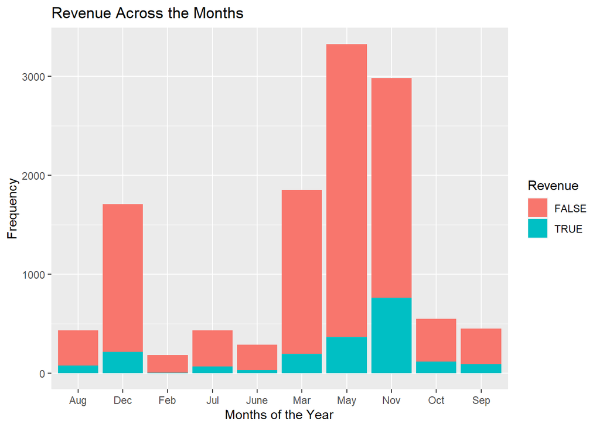

```r
#Plotting a count to understand the relationship Month has on Revenue collected:
Online %>% ggplot() +aes(x = Month, Revenue = ..count../nrow(Online), fill = Revenue) +geom_bar() +
  labs(title = 'Revenue Across the Months', x = 'Months of the Year', y = 'Frequency')
```

In as much as most users visited the site in the month of May, high shopping rates can be observed in the Months of November. This period reported the highest revenue collection as it typically correspond to the ‘shopping season’ in most parts of the world.

- Which Visitors generate more Revenue

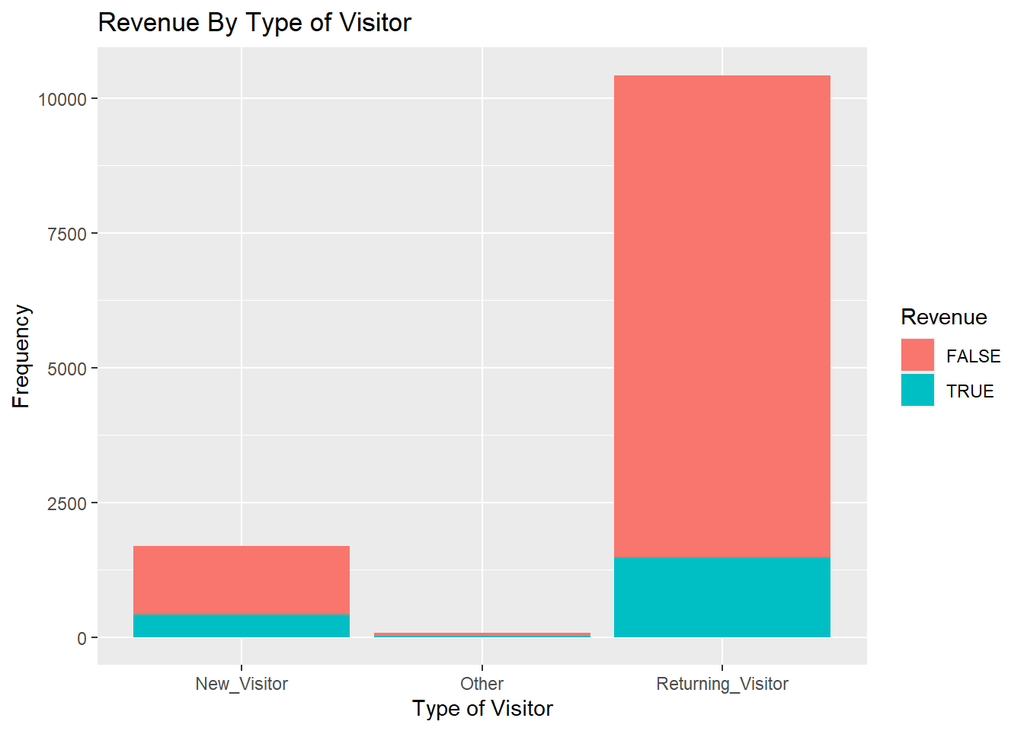

```r
#Plotting a count to understand Revenue by Type of visitor:
Online %>% ggplot() +aes(x = VisitorType, Revenue = ..count../nrow(Online), fill = Revenue) +geom_bar() +
  labs(title = 'Revenue By Type of Visitor', x = 'Type of Visitor', y = 'Frequency')
```

- Does it matter if people visit the website on a weekend or a weekday

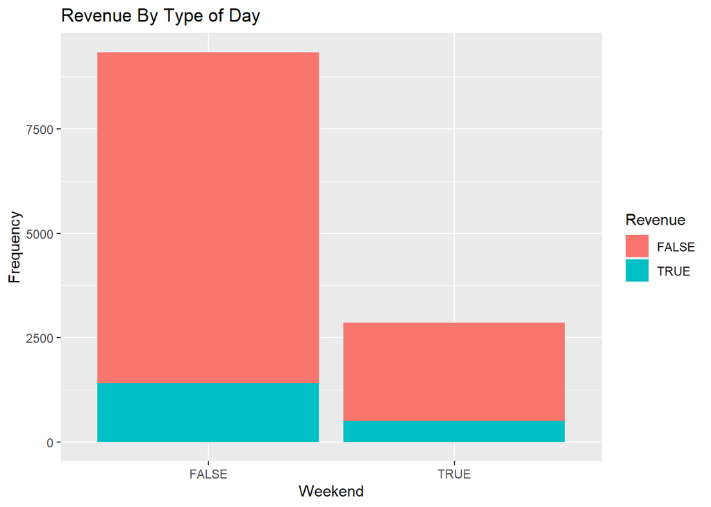

```r
#Plotting a count to understand Revenue by Type of day:
Online %>% ggplot() +aes(x = Weekend, Revenue = ..count../nrow(Online), fill = Revenue) +geom_bar() +
  labs(title = 'Revenue By Type of Day', x = 'Weekend', y = 'Frequency')
```

# Unsupervised Learning Techniques

In this section, K-Means clustering and Hierarchical clustering are to be implemented

```r
#Creating the modelling dataframe:
Model <- copy(Online)

#Dropping unnecessary columns:
#Since Unsupervised Learning requires no Labels, the Revenue column is dropped:
Model = subset(Model, select = -c(Revenue) )

#Viewing the Data types:
sapply(Model, class)
```

```
##          Administrative Administrative_Duration           Informational
##               "integer"               "numeric"               "integer"
##  Informational_Duration          ProductRelated ProductRelated_Duration
##               "numeric"               "integer"               "numeric"
##             BounceRates               ExitRates              PageValues
##               "numeric"               "numeric"               "numeric"
##              SpecialDay                   Month        OperatingSystems
##               "numeric"             "character"               "integer"
##                 Browser                  Region             TrafficType
##               "integer"               "integer"               "integer"
##             VisitorType                 Weekend
##             "character"               "logical"
```

# Feature Engineering

1. Label Encoding

```r
#Encoding Categorical variables to a machine readable format:
Encode <- select(Online,c(Month, VisitorType, Weekend))
Dummy <- dummyVars(" ~ .", data = Encode, fullRank = T)
New_Model <- data.frame(predict(Dummy, newdata = Encode))

# Dropping columns which have already been encoded:
Model = subset(Model, select = -c(Month, VisitorType, Weekend))

#Adding the encoded variables to the dataset:
Model <- cbind(Model,New_Model)

#Previewing the dataframe:
head(Model, n = 2)
```

```
##   Administrative Administrative_Duration Informational Informational_Duration
## 1              0                       0             0                      0
## 2              0                       0             0                      0
##   ProductRelated ProductRelated_Duration BounceRates ExitRates PageValues
## 1              1                       0         0.2       0.2          0
## 2              2                      64         0.0       0.1          0
##   SpecialDay OperatingSystems Browser Region TrafficType MonthDec MonthFeb
## 1          0                1       1      1           1        0        1
## 2          0                2       2      1           2        0        1
##   MonthJul MonthJune MonthMar MonthMay MonthNov MonthOct MonthSep
## 1        0         0        0        0        0        0        0
## 2        0         0        0        0        0        0        0
##   VisitorTypeOther VisitorTypeReturning_Visitor WeekendTRUE
## 1                0                            1           0
## 2                0                            1           0
```

2. Feature Scaling

```r
#Transforming the ranges to the same scale of 0 to 1 using Min Max:
Model <- as.data.frame(sapply(Model, function(x) (x-min(x))/(max(x)-min(x))))

#Previewing the dataframe:
head(Model, n = 2)
```

```
##   Administrative Administrative_Duration Informational Informational_Duration
## 1              0            0.0002941393             0           0.0003920992
## 2              0            0.0002941393             0           0.0003920992
##   ProductRelated ProductRelated_Duration BounceRates ExitRates PageValues
## 1    0.001418440            1.563122e-05           1       1.0          0
## 2    0.002836879            1.016029e-03           0       0.5          0
##   SpecialDay OperatingSystems    Browser Region TrafficType MonthDec MonthFeb
## 1          0        0.0000000 0.00000000      0  0.00000000        0        1
## 2          0        0.1428571 0.08333333      0  0.05263158        0        1
##   MonthJul MonthJune MonthMar MonthMay MonthNov MonthOct MonthSep
## 1        0         0        0        0        0        0        0
## 2        0         0        0        0        0        0        0
##   VisitorTypeOther VisitorTypeReturning_Visitor WeekendTRUE
## 1                0                            1           0
## 2                0                            1           0
```

# Model Training

K-Means Clustering

- Finding K

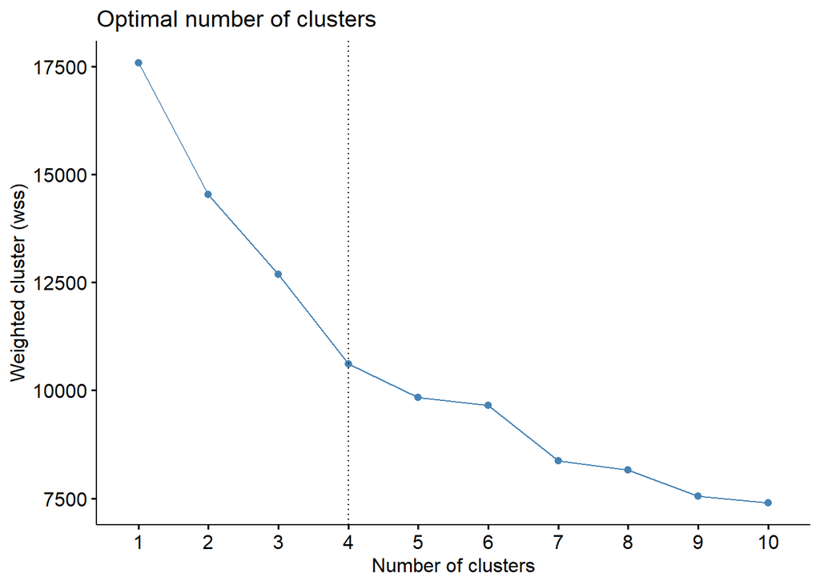

```r
# Finding the optimal number of clusters using the elbow method:
options(repr.plot.width = 6, repr.plot.height = 5)
fviz_nbclust(Model, kmeans, method = 'wss') +
  geom_vline(xintercept = 4, linetype = 3) +
  labs(x = 'Number of clusters', y = 'Weighted cluster (wss)')
```

The Optimal K is 4

```r
# Plotting the K_Mean Clusters with the Optimal K:
New_Model <- kmeans(Model, 4)

# Previewing the number of records in each Cluster:
New_Model$size
```

```
## [1] 2223 1113 5880 2983
```

The number of Clusters are 4 with sizes: 2,223, 1,113, 5,880 and 2,983

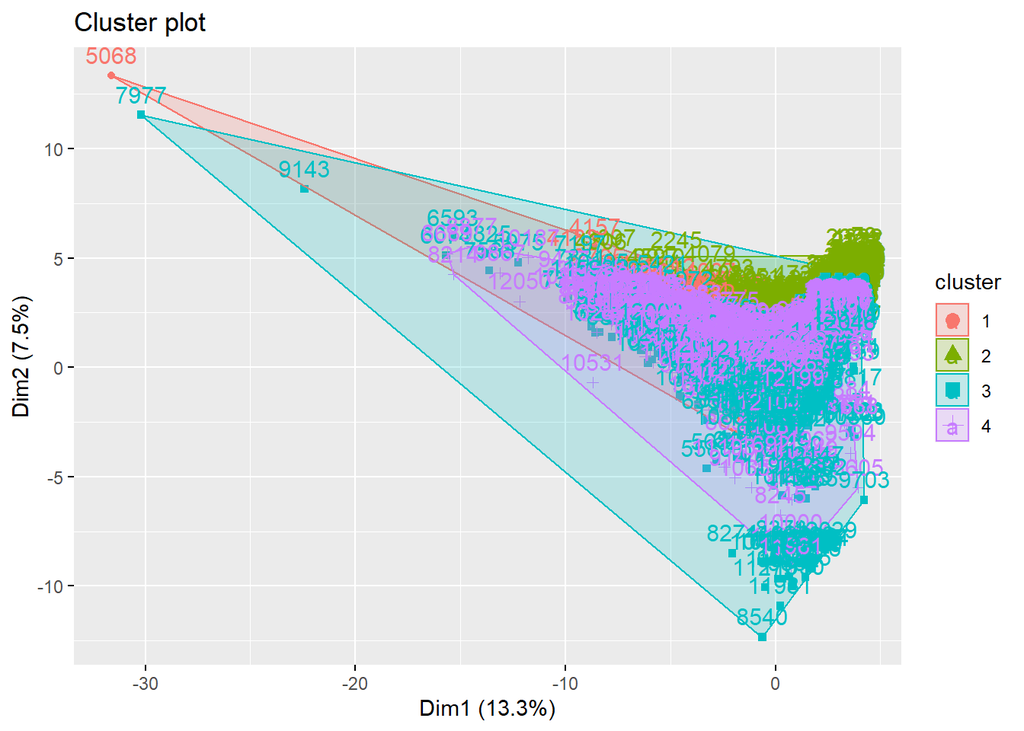

```r
#Plotting the Clusters:
fviz_cluster(New_Model, data = Model)
```

Hierarchical clustering

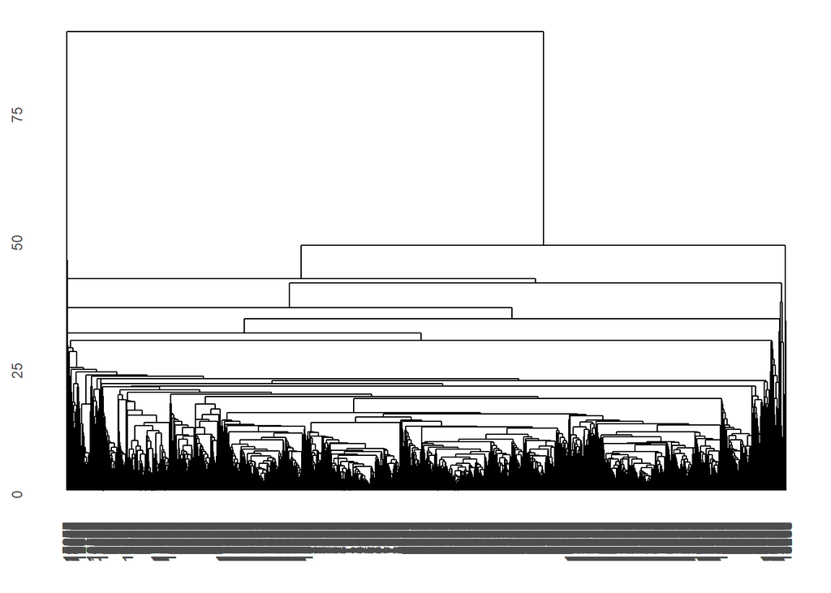

```r
#Using the Manhattan and Average method to perform Hierarchical clustering;
cluster <- scale(Model)
a <- dist(as.matrix(cluster) , method = 'manhattan')
Z <- flashClust(a, method = "average")
ggdendrogram(Z)
```

From the output above, its hard to provide insights on the Clustering.

Comparisons:

- Hierarchical clustering tends to not handle big data well compared to K Means clustering. As a general conclusion, K Mean algorithm is good for large dataset while hierarchical is good for small data.
- K Means needs the number of clusters to be pre-entered while hierarchical has no such requirement. This means Hierarchical is able to deduce the optimal number of clusters.
- K means manually divides data into exclusive subsets while hierarchical arranges it into a tree format.

From the dataset provided, apart from the K Means requiring one to specify the number of clusters, it does not work well with noisy data and outliers.

# Conclusions ans Recommendations

From the Exploratory analysis:

- The data contained Outliers and was highly skewed.
- Anomalies could be detected on the duration variables. I.e: Time cannot have a negative value.
- Few information was provided on the Demographics of the users.

As a recommendation:

- More Information should be collected on the Demographics of the users.
- To counter on the presence of outliers, data validation should be done after collection for verification purposes.
- The company should focus on the best predictors to improve revenue collection.